# Quantile Regression on Synthetic Data

This notebook shows the diagnostic tools applied to quantile regression. For details, see https://arxiv.org/abs/2202.12780.

First, we prepare some plotting settings.

```python
from cycler import cycler
import matplotlib
import matplotlib.pyplot as plt


cmap = matplotlib.colormaps.get_cmap("tab10")
# Swap 3rd with 7th position to make 3rd gray.
color_cy = cycler("color", cmap([0, 1, 7, 2, 3, 4, 5, 6, 8, 9]))
# This can be checked by running
# from matplotlib.colors import ListedColormap
# display(cmap)
# display(ListedColormap(color_cy.by_key()["color"]))

new_cycler = color_cy + cycler(linestyle=["-"] * 2 + ['--'] + ['-'] * 7)
plt.rc('axes', prop_cycle=new_cycler)
```

from cycler import cycler import matplotlib import matplotlib.pyplot as plt cmap = matplotlib.colormaps.get_cmap("tab10") # Swap 3rd with 7th position to make 3rd gray. color_cy = cycler("color", cmap([0, 1, 7, 2, 3, 4, 5, 6, 8, 9])) # This can be checked by running # from matplotlib.colors import ListedColormap # display(cmap) # display(ListedColormap(color_cy.by_key()["color"])) new_cycler = color_cy + cycler(linestyle=["-"] * 2 + ['--'] + ['-'] * 7) plt.rc('axes', prop_cycle=new_cycler)

## 1. Data and Models

We start by creating an artificial dataset with an asymmetric distribution such that mean and median are very different. Then, we fit a linear model and gradient boosted trees for the **75%-quantile**.

```python
import numpy as np
import polars as pl
from sklearn.ensemble import HistGradientBoostingRegressor
from sklearn.linear_model import QuantileRegressor
from sklearn.model_selection import GridSearchCV
from sklearn.pipeline import make_pipeline
from sklearn.preprocessing import SplineTransformer


quantile_level = 0.75

def create_data(n, rng):
    x = np.linspace(start=0, stop=10, num=200)
    y_true_mean = 10 + 0.5 * x * np.sin(x)
    a = 5
    # Note that numpy uses the Lomax version of pareto with mean 1/(a-1).
    y = y_true_mean + 10 * (rng.pareto(a, size=x.shape[0]) - 1 / (a - 1))
    y_true_quantile = y_true_mean + 10 * (
        np.power(1 - quantile_level, -1/a) - 1 - 1 / (a - 1)
    )
    return y, x, y_true_quantile

rng = np.random.RandomState(42)
y_train, x_train, y_quantile_train = create_data(200, rng)
y_test, x_test, y_quantile_test = create_data(100, rng)
X_train, X_test = x_train[:, np.newaxis], x_test[:, np.newaxis]

m_linear = GridSearchCV(
    estimator=make_pipeline(
        SplineTransformer(degree=3),
        QuantileRegressor(quantile=quantile_level, solver="highs"),
    ),
    param_grid={
        "splinetransformer__n_knots": [3, 5, 8, 10],
        "quantileregressor__alpha": np.logspace(-4, 0, 20)
    },
    cv=5,
).fit(X_train, y_train)
print(
    "best (alpha, n_knots) for linear quantile regression = "
    f"({m_linear.best_params_['quantileregressor__alpha']}, "
    f"{m_linear.best_params_['splinetransformer__n_knots']})"
)

m_hgbt = HistGradientBoostingRegressor(
    loss="quantile", quantile=quantile_level
).fit(X_train, y_train)


fig, ax = plt.subplots()
ax.scatter(x_train, y_train, color="black", alpha=0.5)
ax.plot(x_train, m_linear.predict(X_train), label=f"LinReg Quantile: {quantile_level}")
ax.plot(x_train, m_hgbt.predict(X_train), label=f"HGBT Quantile: {quantile_level}")
ax.plot(
    x_train, y_quantile_train, label=f"True {quantile_level}-Quantile",
)
ax.legend()
```

import numpy as np import polars as pl from sklearn.ensemble import HistGradientBoostingRegressor from sklearn.linear_model import QuantileRegressor from sklearn.model_selection import GridSearchCV from sklearn.pipeline import make_pipeline from sklearn.preprocessing import SplineTransformer quantile_level = 0.75 def create_data(n, rng): x = np.linspace(start=0, stop=10, num=200) y_true_mean = 10 + 0.5 * x * np.sin(x) a = 5 # Note that numpy uses the Lomax version of pareto with mean 1/(a-1). y = y_true_mean + 10 * (rng.pareto(a, size=x.shape[0]) - 1 / (a - 1)) y_true_quantile = y_true_mean + 10 * ( np.power(1 - quantile_level, -1/a) - 1 - 1 / (a - 1) ) return y, x, y_true_quantile rng = np.random.RandomState(42) y_train, x_train, y_quantile_train = create_data(200, rng) y_test, x_test, y_quantile_test = create_data(100, rng) X_train, X_test = x_train[:, np.newaxis], x_test[:, np.newaxis] m_linear = GridSearchCV( estimator=make_pipeline( SplineTransformer(degree=3), QuantileRegressor(quantile=quantile_level, solver="highs"), ), param_grid={ "splinetransformer__n_knots": [3, 5, 8, 10], "quantileregressor__alpha": np.logspace(-4, 0, 20) }, cv=5, ).fit(X_train, y_train) print( "best (alpha, n_knots) for linear quantile regression = " f"({m_linear.best_params_['quantileregressor__alpha']}, " f"{m_linear.best_params_['splinetransformer__n_knots']})" ) m_hgbt = HistGradientBoostingRegressor( loss="quantile", quantile=quantile_level ).fit(X_train, y_train) fig, ax = plt.subplots() ax.scatter(x_train, y_train, color="black", alpha=0.5) ax.plot(x_train, m_linear.predict(X_train), label=f"LinReg Quantile: {quantile_level}") ax.plot(x_train, m_hgbt.predict(X_train), label=f"HGBT Quantile: {quantile_level}") ax.plot( x_train, y_quantile_train, label=f"True {quantile_level}-Quantile", ) ax.legend()

```
best (alpha, n_knots) for linear quantile regression = (0.00026366508987303583, 5)
```

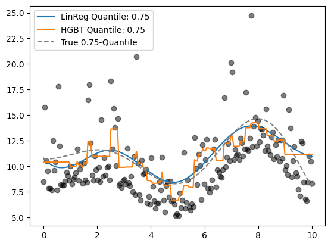

## 2. Calibration Assessment

First, we look at the calibration in total, i.e. neither conditioning on a feature nor on the predictions. We want to predict the 75%-quantile, so we expect that 25% of the data lie above and 75% below the model predictions. This is what the [identification function](https://lorentzenchr.github.io/model-diagnostics/reference/model_diagnostics/calibration/identification/#model_diagnostics.calibration.identification.identification_function) for quantiles actually calculates such that a value of 0 is ideal. Note that the identification function is implicitly called in [`compute_bias`](https://lorentzenchr.github.io/model-diagnostics/reference/model_diagnostics/calibration/identification/#model_diagnostics.calibration.identification.compute_bias) as well as [`plot_bias`](https://lorentzenchr.github.io/model-diagnostics/reference/model_diagnostics/calibration/plots/#model_diagnostics.calibration.plots.plot_bias).

```python
from model_diagnostics.calibration import compute_bias, plot_bias, plot_reliability_diagram

df = pl.DataFrame({
    "linear_quant_reg": m_linear.predict(X_train),
    "hgbt_quant_reg": m_hgbt.predict(X_train),
    "true_quantile": y_quantile_train,
})

compute_bias(y_obs=y_train, y_pred=df, functional="quantile", level=quantile_level)
```

from model_diagnostics.calibration import compute_bias, plot_bias, plot_reliability_diagram df = pl.DataFrame({ "linear_quant_reg": m_linear.predict(X_train), "hgbt_quant_reg": m_hgbt.predict(X_train), "true_quantile": y_quantile_train, }) compute_bias(y_obs=y_train, y_pred=df, functional="quantile", level=quantile_level)

shape: (3, 6)

| model str | bias_mean f64 | bias_count u32 | bias_weights f64 | bias_stderr f64 | p_value f64 |
| --- | --- | --- | --- | --- | --- |
| "linear_quant_r… | 0.005 | 200 | 200.0 | 0.030488 | 0.869899 |
| "hgbt_quant_reg… | 0.0 | 200 | 200.0 | 0.030695 | 1.0 |
| "true_quantile" | -0.005 | 200 | 200.0 | 0.030897 | 0.871607 |

```python
ax = plot_bias(
    y_obs=y_train,
    y_pred=df,
    functional="quantile",
    level=quantile_level,
    confidence_level=1 - 0.9,
)
ax.set_title("Bias Plot on Training Set")
```

ax = plot_bias( y_obs=y_train, y_pred=df, functional="quantile", level=quantile_level, confidence_level=1 - 0.9, ) ax.set_title("Bias Plot on Training Set")

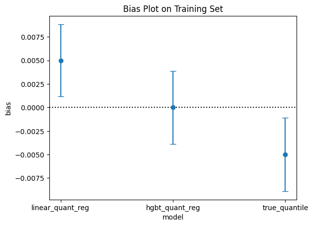

By setting a very small confidence level $\alpha$, such that $1-\alpha$ is in between the p-values, we see that the confidence interval of the linear model does not reach the 0-line while the one of the HGBT model does. Please note that this is a poor choice of a confidence level for this sample size because even the true quantile does not cover the 0-line due to sample uncertainty.

We go on by investigating auto-calibration with the classical tool: a reliability diagram.

```python
%%time
ax = plot_reliability_diagram(
    y_train,
    df,
    functional="quantile",
    level=quantile_level,
    n_bootstrap=100,
)
ax.set_ylim(None, 20)
ax.set_title("Reliability Diagram on Training Set")
```

%%time ax = plot_reliability_diagram( y_train, df, functional="quantile", level=quantile_level, n_bootstrap=100, ) ax.set_ylim(None, 20) ax.set_title("Reliability Diagram on Training Set")

```
CPU times: user 4.3 s, sys: 140 ms, total: 4.44 s
Wall time: 4.83 s
```

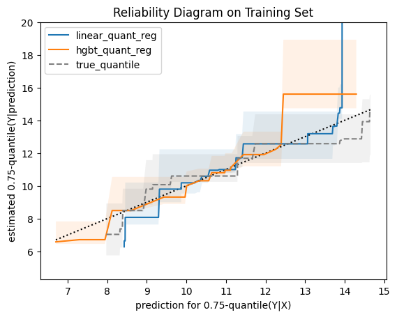

The reliability diagram shows reasonable auto-calibration for both models. For large predicted values, the linear model seems a bit off.

We conclude the assessment of calibration by a bias plot conditional on our single feature.

```python
ax = plot_bias(y_obs=y_train, y_pred=df, feature=x_train, confidence_level=0.9)
ax.set_title("Bias Plot conditional on prediction on Training Set")
```

ax = plot_bias(y_obs=y_train, y_pred=df, feature=x_train, confidence_level=0.9) ax.set_title("Bias Plot conditional on prediction on Training Set")

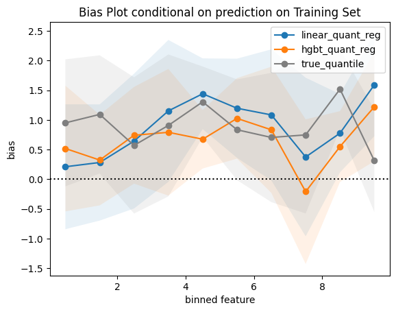

Here again, the HGBT model seems a bit better calibrated.

## 3. Comparison of Model Performance

We use the standard loss function for quantile regression: the pinball loss. Furthermore, as is standard, we do this analysis out-of-sample, i.e. using the test data set.

We report not only the pinball loss or score, but also the additive score decomposition: `score = miscalibration - discrimination + uncertainty`.

```python
from model_diagnostics.scoring import decompose, plot_murphy_diagram, PinballLoss


pbl = PinballLoss(level=quantile_level)
df = pl.DataFrame({
    "linear_quant_reg": m_linear.predict(X_test),
    "hgbt_quant_reg": m_hgbt.predict(X_test),
    "true_quantile": y_quantile_test,
})
decompose(y_obs=y_test, y_pred=df, scoring_function=pbl).sort("score")
```

from model_diagnostics.scoring import decompose, plot_murphy_diagram, PinballLoss pbl = PinballLoss(level=quantile_level) df = pl.DataFrame({ "linear_quant_reg": m_linear.predict(X_test), "hgbt_quant_reg": m_hgbt.predict(X_test), "true_quantile": y_quantile_test, }) decompose(y_obs=y_test, y_pred=df, scoring_function=pbl).sort("score")

shape: (3, 5)

| model str | miscalibration f64 | discrimination f64 | uncertainty f64 | score f64 |
| --- | --- | --- | --- | --- |
| "linear_quant_r… | 0.065729 | 0.24092 | 1.075195 | 0.900004 |
| "true_quantile" | 0.082475 | 0.257558 | 1.075195 | 0.900112 |
| "hgbt_quant_reg… | 0.056078 | 0.206818 | 1.075195 | 0.924455 |

The linear model has a better (lower) out-of-sample score (or loss). While the HGBT has a better miscalibration term (smaller is better), the dominating term is the discrimination (larger is better) where the linear model is clearly superior.

Again, note that there is sample uncertainty. It causes the true quantile to have a slightly worse score than the linear model. A simple t-test will show if the score differences are significant or related to sample uncertainty.

```python
from scipy.stats import ttest_1samp


ttest_1samp(
    pbl.score_per_obs(y_obs=y_test, y_pred=m_linear.predict(X_test))
    - pbl.score_per_obs(y_obs=y_test, y_pred=y_quantile_test),
    popmean=0,
)
```

from scipy.stats import ttest_1samp ttest_1samp( pbl.score_per_obs(y_obs=y_test, y_pred=m_linear.predict(X_test)) - pbl.score_per_obs(y_obs=y_test, y_pred=y_quantile_test), popmean=0, )

```
TtestResult(statistic=-0.005514228985365129, pvalue=0.9956058279989309, df=199)
```

The test statistic is negative which means that the score of the linear model is better than the one of the true quantile. With the very large p-value, however, we cannot reject the null hypothesis of equal mean values, i.e. equal scores. It means that we do not have statistical evidence to say that any one of the linear and the true model performs better.

We play the same game and perform a t-test for the score difference of the linear and the HGBT models.

```python
ttest_1samp(
    pbl.score_per_obs(y_obs=y_test, y_pred=m_linear.predict(X_test))
    - pbl.score_per_obs(y_obs=y_test, y_pred=m_hgbt.predict(X_test)),
    popmean=0,
)
```

ttest_1samp( pbl.score_per_obs(y_obs=y_test, y_pred=m_linear.predict(X_test)) - pbl.score_per_obs(y_obs=y_test, y_pred=m_hgbt.predict(X_test)), popmean=0, )

```
TtestResult(statistic=-1.1262034739249922, pvalue=0.26143569923373233, df=199)
```

All of the above score analysis was based on the pinball loss, but there are other possible choices. Does the ranking of the models change with the choice of a scoring function? This can be analysed by means of the Murphy diagram. The x-axis `eta` specifies different scoring/loss functions, all consistent for the 75%-quantile.

```python
plot_murphy_diagram(y_obs=y_test, y_pred=df, functional="quantile", level=quantile_level)
```

plot_murphy_diagram(y_obs=y_test, y_pred=df, functional="quantile", level=quantile_level)

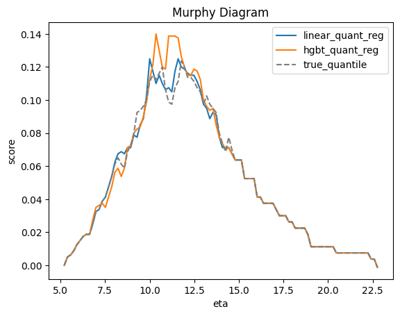

The linear model seems indeed to be superior over a range of `eta` values.